# Tarea 8: Ames Housing

Las variables de este conjunto son:

- SalePrice - the property’s sale price in dollars. This is the target variable that you’re trying to predict.
- MSSubClass: The building class
- MSZoning: The general zoning classification
- LotFrontage: Linear feet of street connected to property
- LotArea: Lot size in square feet
- Street: Type of road access
- Alley: Type of alley access
- LotShape: General shape of property
- LandContour: Flatness of the property
- Utilities: Type of utilities available
- LotConfig: Lot configuration
- LandSlope: Slope of property
- Neighborhood: Physical locations within Ames city limits
- Condition1: Proximity to main road or railroad
- Condition2: Proximity to main road or railroad (if a second is present)
- BldgType: Type of dwelling
- HouseStyle: Style of dwelling
- OverallQual: Overall material and finish quality
- OverallCond: Overall condition rating
- YearBuilt: Original construction date
- YearRemodAdd: Remodel date
- RoofStyle: Type of roof
- RoofMatl: Roof material
- Exterior1st: Exterior covering on house
- Exterior2nd: Exterior covering on house (if more than one material)
- MasVnrType: Masonry veneer type
- MasVnrArea: Masonry veneer area in square feet
- ExterQual: Exterior material quality
- ExterCond: Present condition of the material on the exterior
- Foundation: Type of foundation
- BsmtQual: Quality of the basement
- BsmtCond: General condition of the basement
- BsmtExposure: Walkout or garden level basement walls
- BsmtFinType1: Quality of basement finished area
- BsmtFinSF1: Type 1 finished square feet
- BsmtFinType2: Quality of second finished area (if present)
- BsmtFinSF2: Type 2 finished square feet
- BsmtUnfSF: Unfinished square feet of basement area
- TotalBsmtSF: Total square feet of basement area
- Heating: Type of heating
- HeatingQC: Heating quality and condition
- CentralAir: Central air conditioning
- Electrical: Electrical system
- 1stFlrSF: First Floor square feet
- 2ndFlrSF: Second floor square feet
- LowQualFinSF: Low quality finished square feet (all floors)
- GrLivArea: Above grade (ground) living area square feet
- BsmtFullBath: Basement full bathrooms
- BsmtHalfBath: Basement half bathrooms
- FullBath: Full bathrooms above grade
- HalfBath: Half baths above grade
- Bedroom: Number of bedrooms above basement level
- Kitchen: Number of kitchens
- KitchenQual: Kitchen quality
- TotRmsAbvGrd: Total rooms above grade (does not include bathrooms)
- Functional: Home functionality rating
- Fireplaces: Number of fireplaces
- FireplaceQu: Fireplace quality
- GarageType: Garage location
- GarageYrBlt: Year garage was built
- GarageFinish: Interior finish of the garage
- GarageCars: Size of garage in car capacity
- GarageArea: Size of garage in square feet
- GarageQual: Garage quality
- GarageCond: Garage condition
- PavedDrive: Paved driveway
- WoodDeckSF: Wood deck area in square feet
- OpenPorchSF: Open porch area in square feet
- EnclosedPorch: Enclosed porch area in square feet
- 3SsnPorch: Three season porch area in square feet
- ScreenPorch: Screen porch area in square feet
- PoolArea: Pool area in square feet
- PoolQC: Pool quality
- Fence: Fence quality
- MiscFeature: Miscellaneous feature not covered in other categories
- MiscVal: $Value of miscellaneous feature
- MoSold: Month Sold
- YrSold: Year Sold
- SaleType: Type of sale
- SaleCondition: Condition of sale

Podemos ver los niveles de cada variable y más explicaciones en el archivo *data/houseprices/data_description.txt*

```r
library(tidyverse)

entrena <- read_csv('../../../datos/houseprices/house-prices-train.csv')
prueba  <- read_csv('../../../datos/houseprices/house-prices-test.csv')
nrow(entrena)
```

```
## [1] 1460
```

```r
nrow(prueba)
```

```
## [1] 1459
```

```r
head(entrena)
```

| Id | MSSubClass | MSZoning | LotFrontage | LotArea | Street | Alley | LotShape | LandContour | Utilities | LotConfig | LandSlope | Neighborhood | Condition1 | Condition2 | BldgType | HouseStyle | OverallQual | OverallCond | YearBuilt | YearRemodAdd | RoofStyle | RoofMatl | Exterior1st | Exterior2nd | MasVnrType | MasVnrArea | ExterQual | ExterCond | Foundation | … |
| --- | --- | --- | --- | --- | --- | --- | --- | --- | --- | --- | --- | --- | --- | --- | --- | --- | --- | --- | --- | --- | --- | --- | --- | --- | --- | --- | --- | --- | --- | --- |
| 1 | 60 | RL | 65 | 8450 | Pave | NA | Reg | Lvl | AllPub | Inside | Gtl | CollgCr | Norm | Norm | 1Fam | 2Story | 7 | 5 | 2003 | 2003 | Gable | CompShg | VinylSd | VinylSd | BrkFace | 196 | Gd | TA | PConc | … |
| 2 | 20 | RL | 80 | 9600 | Pave | NA | Reg | Lvl | AllPub | FR2 | Gtl | Veenker | Feedr | Norm | 1Fam | 1Story | 6 | 8 | 1976 | 1976 | Gable | CompShg | MetalSd | MetalSd | None | 0 | TA | TA | CBlock | … |
| 3 | 60 | RL | 68 | 11250 | Pave | NA | IR1 | Lvl | AllPub | Inside | Gtl | CollgCr | Norm | Norm | 1Fam | 2Story | 7 | 5 | 2001 | 2002 | Gable | CompShg | VinylSd | VinylSd | BrkFace | 162 | Gd | TA | PConc | … |
| 4 | 70 | RL | 60 | 9550 | Pave | NA | IR1 | Lvl | AllPub | Corner | Gtl | Crawfor | Norm | Norm | 1Fam | 2Story | 7 | 5 | 1915 | 1970 | Gable | CompShg | Wd Sdng | Wd Shng | None | 0 | TA | TA | BrkTil | … |
| 5 | 60 | RL | 84 | 14260 | Pave | NA | IR1 | Lvl | AllPub | FR2 | Gtl | NoRidge | Norm | Norm | 1Fam | 2Story | 8 | 5 | 2000 | 2000 | Gable | CompShg | VinylSd | VinylSd | BrkFace | 350 | Gd | TA | PConc | … |
| 6 | 50 | RL | 85 | 14115 | Pave | NA | IR1 | Lvl | AllPub | Inside | Gtl | Mitchel | Norm | Norm | 1Fam | 1.5Fin | 5 | 5 | 1993 | 1995 | Gable | CompShg | VinylSd | VinylSd | None | 0 | TA | TA | Wood | … |

```r
entrena_larga <- entrena %>% gather(variable, valor, -Id)
prueba_larga <- prueba %>% gather(variable, valor, -Id)
```

## Distribuciones de variable respuesta y otras

Consideramos algunas variables que sabemos deben ser importantes y algunas gráficas. Vamos a predecir el logaritmo, pues la variable respuesta varía al menos en un orden de magnitud y la estructura multiplicativa del modelo con logaritmo puede ser más apropiada para esta problema (también ayuda comprimiendo valores altos de la variable respuesta).

```r
table(is.na(entrena$SalePrice))
```

```
##
## FALSE
##  1460
```

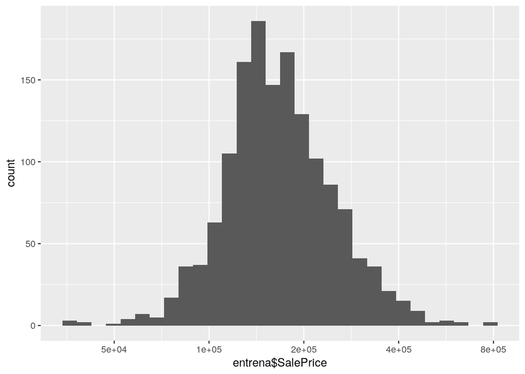

```r
qplot(entrena$SalePrice) + scale_x_log10(breaks= 100000*c(0.5,1,2,4,8))
```

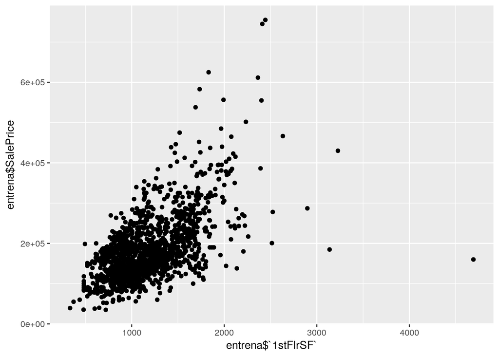

```r
qplot(entrena$`1stFlrSF`, entrena$SalePrice)
```

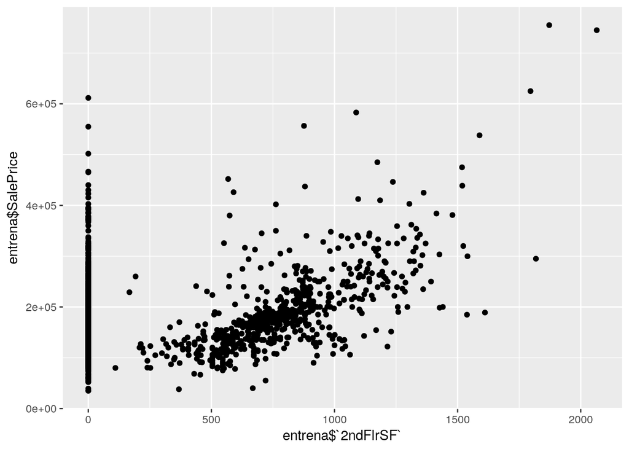

```r
qplot(entrena$`2ndFlrSF`, entrena$SalePrice)
```

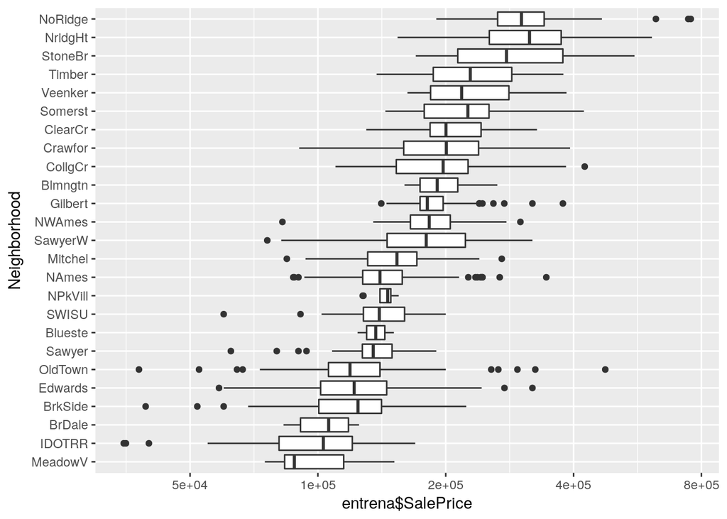

```r
entrena$Neighborhood <- reorder(entrena$Neighborhood, entrena$SalePrice)
ggplot(entrena, aes(x=Neighborhood, y= entrena$SalePrice)) + geom_boxplot() +
  coord_flip() + scale_y_log10(breaks= 100000*c(0.5,1,2,4,8))
```

## Datos faltantes

Contar faltantes

```r
faltantes <- entrena_larga %>% group_by(variable) %>%
  summarise(na_conteo = sum(is.na(valor)), val_distintos = length(unique(valor)),
            categorica = all(is.na(as.numeric(valor)))) %>%
  arrange(desc(na_conteo)) %>% print(n = 20)
```

[output not shown]

[output cut: 73 more lines]

[output not shown]

```
## # A tibble: 80 x 4
##        variable na_conteo val_distintos categorica
##           <chr>     <int>         <int>      <lgl>
##  1       PoolQC      1453             4       TRUE
##  2  MiscFeature      1406             5       TRUE
##  3        Alley      1369             3       TRUE
##  4        Fence      1179             5       TRUE
##  5  FireplaceQu       690             6       TRUE
##  6  LotFrontage       259           111      FALSE
##  7   GarageCond        81             6       TRUE
##  8 GarageFinish        81             4       TRUE
##  9   GarageQual        81             6       TRUE
## 10   GarageType        81             7       TRUE
## 11  GarageYrBlt        81            98      FALSE
## 12 BsmtExposure        38             5       TRUE
## 13 BsmtFinType2        38             7       TRUE
## 14     BsmtCond        37             5       TRUE
## 15 BsmtFinType1        37             7       TRUE
## 16     BsmtQual        37             5       TRUE
## 17   MasVnrArea         8           328      FALSE
## 18   MasVnrType         8             5       TRUE
## 19   Electrical         1             6       TRUE
## 20     1stFlrSF         0           753      FALSE
## # ... with 60 more rows
```

```r
filter(faltantes, categorica)
```

| variable | na_conteo | val_distintos | categorica |
| --- | --- | --- | --- |
| PoolQC | 1453 | 4 | TRUE |
| MiscFeature | 1406 | 5 | TRUE |
| Alley | 1369 | 3 | TRUE |
| Fence | 1179 | 5 | TRUE |
| FireplaceQu | 690 | 6 | TRUE |
| GarageCond | 81 | 6 | TRUE |
| GarageFinish | 81 | 4 | TRUE |
| GarageQual | 81 | 6 | TRUE |
| GarageType | 81 | 7 | TRUE |
| BsmtExposure | 38 | 5 | TRUE |

[output cut: 33 more lines]

```r
filter(faltantes, !categorica)
```

| variable | na_conteo | val_distintos | categorica |
| --- | --- | --- | --- |
| LotFrontage | 259 | 111 | FALSE |
| GarageYrBlt | 81 | 98 | FALSE |
| MasVnrArea | 8 | 328 | FALSE |
| 1stFlrSF | 0 | 753 | FALSE |
| 2ndFlrSF | 0 | 417 | FALSE |
| 3SsnPorch | 0 | 20 | FALSE |
| BedroomAbvGr | 0 | 8 | FALSE |
| BsmtFinSF1 | 0 | 637 | FALSE |
| BsmtFinSF2 | 0 | 144 | FALSE |
| BsmtFullBath | 0 | 4 | FALSE |

[output cut: 27 more lines]

Estas variables son faltantes cuando no hay alberca, otros features, callejón, reja, chimenea, o está conectada a la calle:

- PoolQC: Pool quality
- MiscFeature: Miscellaneous feature not covered in other categories
- Alley: Type of alley access
- Fence: Fence quality
- FireplaceQu: Fireplace quality
- LotFrontage: Linear feet of street connected to property

Estas variables son faltantes cuando la casa no tiene garage:

- GarageType: Garage location
- GarageYrBlt: Year garage was built
- GarageFinish: Interior finish of the garage
- GarageCars: Size of garage in car capacity
- GarageArea: Size of garage in square feet
- GarageQual: Garage quality
- GarageCond: Garage condition

Cuando no tienen sótano:

- BsmtQual: Quality of the basement
- BsmtCond: General condition of the basement
- BsmtExposure: Walkout or garden level basement walls
- BsmtFinType1: Quality of basement finished area
- BsmtFinType2: Quality of second finished area (if present)

Cuando no tienen masonry veneer:

- MasVnrType: Masonry veneer type
- MasVnrArea: Masonry veneer area in square feet

Y hay un faltante en la variable *Electrical*. Hay varias opciones para tratar con datos faltantes (por ejemplo, existe la función *rfImpute*). Sin embargo, estos son faltantes son estructurales (la medición de calidad de alberca no existe si no hay alberca - no son datos censurados por algún proceso).

```r
vars_faltantes <- filter(faltantes, na_conteo > 0) %>% pull(variable)
niveles_faltantes <- entrena_larga %>%  filter(variable %in% vars_faltantes) %>%
  group_by(variable) %>% mutate(n_distintos=n_distinct(valor)) %>%
  group_by(variable, valor) %>%
  summarise(n = n(), n_distintos = first(n_distintos))

niveles_faltantes %>% filter(n_distintos < 50)
```

| variable | valor | n | n_distintos |
| --- | --- | --- | --- |
| Alley | Grvl | 50 | 3 |
| Alley | Pave | 41 | 3 |
| Alley | NA | 1369 | 3 |
| BsmtCond | Fa | 45 | 5 |
| BsmtCond | Gd | 65 | 5 |
| BsmtCond | Po | 2 | 5 |
| BsmtCond | TA | 1311 | 5 |
| BsmtCond | NA | 37 | 5 |
| BsmtExposure | Av | 221 | 5 |
| BsmtExposure | Gd | 134 | 5 |

[output cut: 76 more lines]

Por lo pronto, recordamos que tenemos que correr un modelo lo más pronto posible. Usamos el siguiente script para limpiar faltantes, que asigna a la categoría más popular los faltantes categóricos y la media a los faltantes numéricos.

**Discusión**: aunque en esta parte vamos a usar error OOB para seleccionar modelos, no es una idea tan buena (pues utilizamos todos los datos para imputar medias y categoría modal, y OOB utiliza esta información). Esto puede hacer optimista la estimación OOB como estimación del error de predicción. Más adelante usamos otra estrategia que no tiene este problema (ve la función limpiar_faltantes_2 más adelante).

```r
limpiar_faltantes <- function(datos, datos_p = NULL, to_factor = FALSE){
  #limpieza de faltantes y tipos de variables
  if(is.null(datos_p)){
    datos_p <- datos
  }
  #abajo vamos a inferir el tipo de variable, pero podemos tener error si hay
  #variables categóricas codificadas con números. Viendo data_description.txt, solo hay
  #una, que arreglamos así:
  datos <- datos %>% group_by(variable) %>% mutate(valor = ifelse(variable!='MSSubClass', valor, paste0('nivel_',valor)))
  datos_p <- datos_p %>% group_by(variable) %>% mutate(valor = ifelse(variable!='MSSubClass', valor,paste0('nivel_',valor)))
  # inferir el tipo de variable (categórica o numérica)
  tipo_vars <- datos %>% group_by(variable) %>%
    summarise(categorica = all(is.na(as.numeric(valor))))
  datos <- datos %>% left_join(tipo_vars) %>% ungroup
  datos_p <- datos_p %>% left_join(tipo_vars) %>% ungroup


  #medias de datos de entrenamiento
  datos_num_medias <- datos %>% filter(!categorica) %>%
                mutate(valor = as.numeric(valor)) %>%
                group_by(variable) %>%
                summarise(media = mean(valor, na.rm = TRUE))

  #categoría más popular de datos de entrenamiento
  cats <- datos %>% filter(categorica) %>%
                    group_by(variable, valor) %>%
                           summarise(n = n()) %>%
                           filter(!is.na(valor))

   max_cat <- cats %>% group_by(variable) %>%
                           summarise(max_cat = valor[which.max(n)])

   cats <- cats %>% select(variable, valor) %>% group_by(variable) %>% nest
  #imputación
  datos_cat <- datos_p %>% filter(categorica)
  datos_num <- datos_p %>% filter(!categorica)

  #procesar categóricas
  datos_cat <- datos_cat %>% left_join(max_cat %>% select(variable, max_cat)) %>%
                             group_by(variable) %>%
                             mutate(valor = ifelse(is.na(valor), max_cat, valor))
  #quitar factores nuevos en datos de prueba
  datos_cat <- datos_cat %>% group_by(variable) %>% left_join(cats) %>%
          group_by(variable) %>%
          mutate(valor = ifelse(valor %in% first(data), valor, max_cat[1]))

  datos_1 <- datos_cat %>% select(Id, variable, valor) %>%
                           spread(variable, valor, convert=TRUE)
  if(to_factor){
    datos_1 <- datos_1 %>% unclass %>% data.frame
  }
  # procesar numéricas
  datos_2 <- datos_num %>% left_join(datos_num_medias) %>%
                           mutate(valor = ifelse(is.na(valor), media,  valor)) %>%
                           select(Id, variable, valor) %>%
                           spread(variable, valor, convert=TRUE)
  # unir tablas
  bind_cols(datos_1, datos_2)
  }
```

## Bosque aleatorio

Podemos intentar construir un bosque con esta primera aproximación de datos. Vamos a usar el logaritmo del precio (por el análisis que vimos arriba). No es necesario log-transformar las otras variables para bosques aleatorios (pues es una transformación monótona). Preparamos los datos:

```r
library(randomForest)
entrena_na <- limpiar_faltantes(entrena_larga, to_factor = TRUE) %>%
  select(-Id, -Utilities) %>% as.data.frame
prueba_na <- limpiar_faltantes(entrena_larga, prueba_larga, to_factor = TRUE) %>%
  select(-Id, -Utilities) %>% as.data.frame
names(entrena_na) <- paste('v', names(entrena_na), sep='') #evitar nombres no válidos de variables
names(prueba_na) <- paste('v', names(prueba_na), sep='') #evitar nombres no válidos de variables
```

Corremos el bosque:

```r
set.seed(2912)
bosque_precios <- randomForest(log(vSalePrice) ~., data = entrena_na,
                               mtry = 10, ntree=1500, importance=TRUE)
bosque_precios
```

```
##
## Call:
##  randomForest(formula = log(vSalePrice) ~ ., data = entrena_na,      mtry = 10, ntree = 1500, importance = TRUE)
##                Type of random forest: regression
##                      Number of trees: 1500
## No. of variables tried at each split: 10
##
##           Mean of squared residuals: 0.02074603
##                     % Var explained: 86.99
```

Y examinamos la evolución del error al agregar más árboles y el error final (OOB)

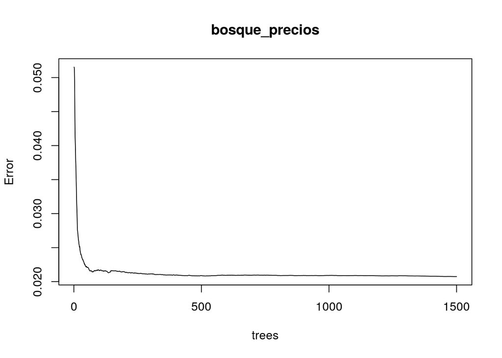

```r
plot(bosque_precios)
```

```r
sqrt(last(bosque_precios$mse))
```

```
## [1] 0.1440348
```

Y podemos ver las importancias, que dan resultados interesantes (nótese que hay varias variables de superficies en pies cuadrados) :

```r
imp <-  importance(bosque_precios)[,1]
data_frame( variable = names(imp), importance = round(imp,1)) %>% arrange(desc(imp))
```

| variable | importance |
| --- | --- |
| vGrLivArea | 43.1 |
| vOverallQual | 41.6 |
| vTotalBsmtSF | 40.2 |
| v1stFlrSF | 35.9 |
| vOverallCond | 35.2 |
| vYearBuilt | 34.7 |
| vLotArea | 34.0 |
| vFireplaces | 32.4 |
| v2ndFlrSF | 31.8 |
| vYearRemodAdd | 31.1 |

[output cut: 69 more lines]

Y además podemos ver cómo se comparan las predicciones OOB con la variable que queremos predecir:

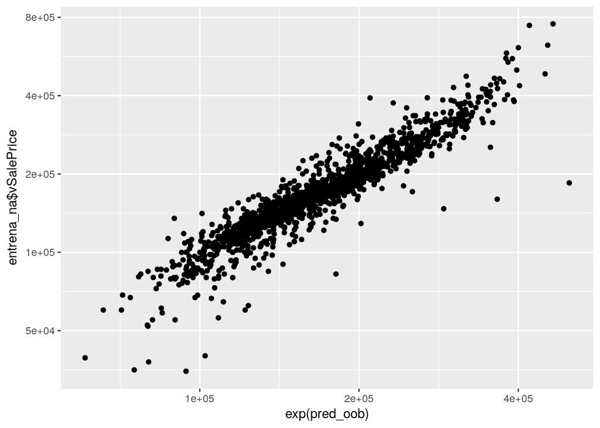

```r
pred_oob <- predict(bosque_precios)
qplot(exp(pred_oob), entrena_na$vSalePrice) +
  scale_x_log10(breaks= 100000*c(0.5,1,2,4,8))+
  scale_y_log10(breaks= 100000*c(0.5,1,2,4,8))
```

Error de entrenamiento

```r
pred_entrena <- predict(bosque_precios, newdata = entrena_na)
sd(pred_entrena-log(entrena_na$vSalePrice))
```

```
## [1] 0.06750791
```

Lo que indica que podemos trabajar tanto con sesgo como varianza. Podemos mejorar haciendo algunas transformaciones de variable. Pero antes, afinamos los parámetros del bosque:

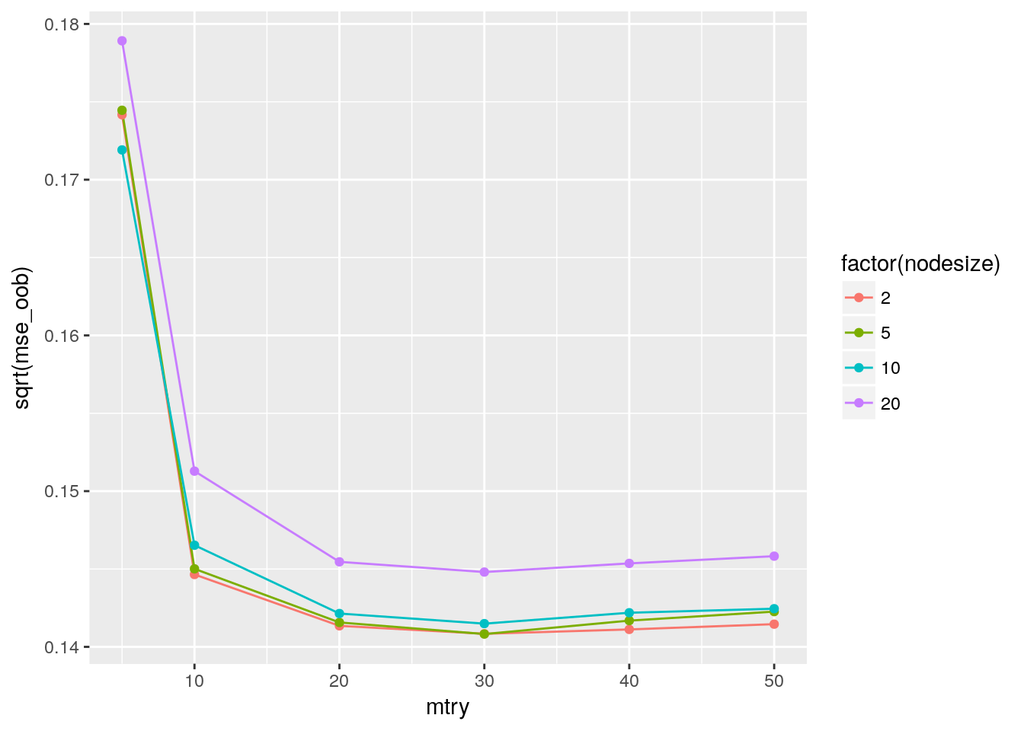

```r
entrena_na <- limpiar_faltantes(entrena_larga, to_factor = TRUE) %>%
  select(-Id, -Utilities)
names(entrena_na) <- paste('v', names(entrena_na), sep='')

bosque_oob <- function(entrena_na, mtry, nodesize){
  bosque_precios <- randomForest(log(vSalePrice) ~., data = entrena_na,
                               mtry = mtry, ntree = 500, nodesize = nodesize,
                               importance=TRUE)
  error_oob <- last(bosque_precios$mse)
  #print(paste(c('mtry:', mtry, ' nodesize:', nodesize, ' ErrorOOB:', round(sqrt(error_oob),4)), collapse=''))
  error_oob
}
df_res <- expand.grid(mtry = c(5,10,20,30,40,50), nodesize = c(2,5,10,20))
df_res <- df_res %>% rowwise %>% mutate(mse_oob = bosque_oob(entrena_na, mtry, nodesize))
ggplot(df_res, aes(x=mtry, y= sqrt(mse_oob), colour=factor(nodesize), group=nodesize)) + geom_line() + geom_point()
```

```r
sqrt(min(df_res$mse_oob))
```

```
## [1] 0.1408239
```

## Otras opciones para datos faltantes

Ahora podemos refinar nuestro script de faltantes. Todas estas opciones pueden ayudar o no en la predicción. Podemos:

- Usar una categoría adicional “No disponible” para faltantes estructurales (por ejemplo, condiciones del garage si no hay garage)
- Para variables numéricas, imputar 0 cuando sea más apropiado (por ejemplo, tamaño de “Frontage” si no conecta con la calle)

```r
limpiar_faltantes_2 <- function(datos, datos_p = NULL, min_cat = 10,
                              to_factor = FALSE){
  #limpieza de faltantes y tipos de variables
  if(is.null(datos_p)){
    datos_p <- datos
  }
  #abajo vamos a inferir el tipo de variable, pero podemos tener error si hay
  #variables categóricas codificadas con números. Viendo data_description.txt, solo hay
  #una, que arreglamos así:
  datos <- datos %>% group_by(variable) %>%
    mutate(valor =ifelse(variable!='MSSubClass', valor, paste0('nivel_',valor)))
  datos_p <- datos_p %>% group_by(variable) %>%
    mutate(valor = ifelse(variable!='MSSubClass', valor,paste0('nivel_',valor)))

  # inferir el tipo de variable (categórica o numérica)
  tipo_vars <- datos %>% group_by(variable) %>%
    summarise(categorica = all(is.na(as.numeric(valor))))
  datos <- datos %>% left_join(tipo_vars) %>% ungroup
  datos_p <- datos_p %>% left_join(tipo_vars) %>% ungroup


  #valores a imputar para numéricas (ver análisis del principio: usamos 0)
  datos_num_medias <- datos %>% filter(!categorica) %>%
                group_by(variable) %>%
                summarise(media = 0)


  # Reasignación para categóricas
  reasignar <- datos %>% filter(categorica) %>%
                         mutate(valor_nuevo = ifelse(is.na(valor), 'no-disponible', valor)) #%>%
                         #group_by(variable, valor) %>%
                         #summarise(n = n()) #%>%
                         #mutate(valor_nuevo = ifelse(n <= min_cat, 'Otros' , valor))

  #imputación
  datos_cat <- datos_p %>% filter(categorica)
  datos_num <- datos_p %>% filter(!categorica)


  #procesar categóricas
  #primero agregamos categoría no disponible
  datos_cat <- datos_cat %>% mutate(valor = ifelse(is.na(valor), 'no-disponible' ,valor))

  # aquí falta limpiar cateogrías nuevas en muestra de prueba
  datos_1 <- datos_cat %>% select(Id, variable, valor) %>%
                           spread(variable, valor, convert=TRUE)
  if(to_factor){
    datos_1 <- datos_1 %>% unclass %>% data.frame
  }
  # procesar numéricas
  datos_2 <- datos_num %>% left_join(datos_num_medias) %>%
                           mutate(valor = ifelse(is.na(valor), media,  valor)) %>%
                           select(Id, variable, valor) %>%
                           spread(variable, valor, convert=TRUE)
  # unir tablas
  bind_cols(datos_1, datos_2)
  }
```

```r
entrena_na <- limpiar_faltantes_2(entrena_larga, to_factor = TRUE) %>%
  select(-Id, -Utilities) %>% as.data.frame
prueba_na <- limpiar_faltantes_2(entrena_larga, prueba_larga, to_factor = TRUE) %>%
  select(-Id, -Utilities) %>% as.data.frame
#write_rds(entrena_na, 'datos/ameshousing-entrena-procesado.rds')
names(entrena_na) <- paste('v', names(entrena_na), sep='')
names(prueba_na) <- paste('v', names(prueba_na), sep='')

table(entrena_na$vPoolQC)
```

```
##
##            Ex            Fa            Gd no-disponible
##             2             2             3          1453
```

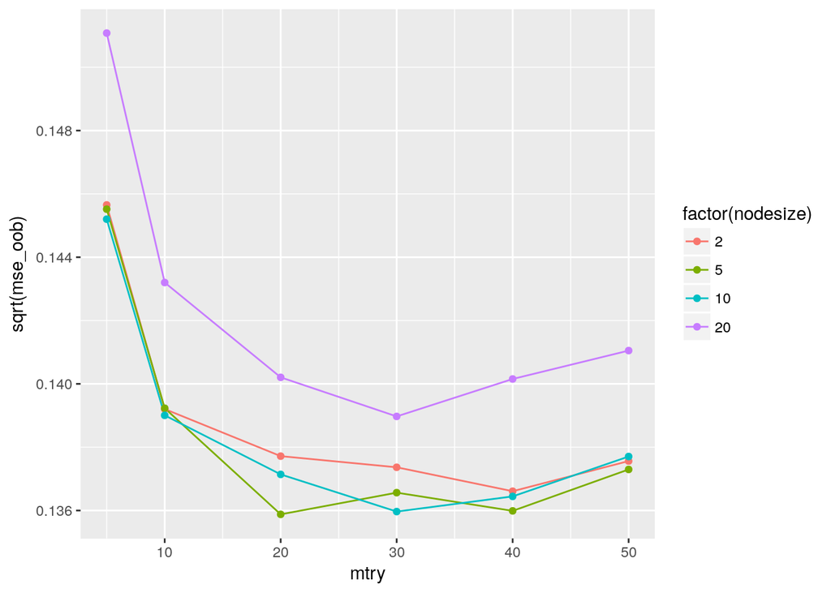

```r
df_res <- expand.grid(mtry = c(5,10,20,30,40,50), nodesize = c(2,5,10,20))
df_res <- df_res %>% rowwise %>% mutate(mse_oob = bosque_oob(entrena_na, mtry, nodesize))
ggplot(df_res, aes(x=mtry, y= sqrt(mse_oob), colour=factor(nodesize), group=nodesize)) + geom_line() + geom_point()
```

```r
sqrt(min(df_res$mse_oob))
```

```
## [1] 0.135879
```